# OutFLANK: Finding FST outliers with an inferred neutral distribution

Katie E. Lotterhos

OutFLANK is an R package that implements the method developed by Whitlock and Lotterhos to use likelihood on a trimmed distribution of $F_{ST}$ values to infer the distribution of $F_{ST}$ for neutral markers. This distribution is then used to assign q-values to each locus to detect outliers that may be due to spatially heterogeneous selection.

If you use OutFLANK, please cite:

Whitlock, M. C., and K. E. Lotterhos. Reliable detection of loci responsible for local adaptation: Inference of a neutral model through trimming the distribution of FST. *Accepted* at The American Naturalist.

Please see this paper for a discussion of the limitations and strengths of this approach.

## To load OutFLANK

OutFLANK is distributed through github. To install the OutFLANK package, first install the devtools package on your session of R, followed by the installation of OutFLANK from github.

```r
### Install required package devtools if not installed
if (!("devtools" %in% installed.packages())){install.packages("devtools")}
library(devtools)

### Install required package qvalue if not installed
if (!("qvalue" %in% installed.packages())){
  source("http://bioconductor.org/biocLite.R")
  biocLite("qvalue")
  }

### Install OutFLANK if not installed
if (!("OutFLANK" %in% installed.packages())){install_github("whitlock/OutFLANK")}

if (!("vcfR" %in% installed.packages())){install.packages("vcfR")}
```

Next, load the packages into your R session. In later uses of the package, you can start with this library step. It will automatically load the `qvalue` library.

```r
library(OutFLANK)
library(vcfR)
```

## Steps to running OutFLANK

1. Prepare a dataframe for the OutFLANK function
   - From a formatted SNP dataset using `MakeDiploidFSTMat()`
   - From your own data using functions provided with the package (see Section “For Advanced Users”)
2. Check for SNPs of low sample size or that have $F_{ST}$ values differentially affected by sample size correction
3. Run OutFLANK
4. Plot results, and re-run OutFLANK if necessary

## Preparing input files for OutFLANK

The input for the `OutFLANK()` function is a data frame, with a row for each locus. OutFLANK requires that the input data include a large number of loci not strongly affected by spatially heterogeneous selection, although these need not be previously identified. It will work best with at least thousands of loci in the data set.

OutFLANK finds outliers for $F_{ST}$, but it needs to use estimates of FST that have not been corrected for sample size adjustments. This is because these sample size adjustments can sometimes cause the estimate of the FST of a locus to be negative, which is not a possible value of the chi-squared distribution used by OutFLANK. These uncorrected values are labeled with “NoCorr”, e.g. FSTNoCorr is the FST of a locus without this correction. (In order to properly average FST over loci, OutFLANK also needs the numerator and denominator of the FST calculation for FSTNoCorr; these are called T1NoCorr and T2NoCorr respectively, for more information see the section “For Advanced Users”).

Since only uncorrected values of Fst are used in the algorithm, loci with unusually low sample sizes relative to the rest of the loci could be called as outliers. The user should take care to remove them before analysis. For a discussion of this issue see the publication.

There are several required columns in the input data frame, which you can read about in the section “Running OutFLANK”. Some of the columns in the input are somewhat unusual, and functions to create the values in these columns are also included in the package. We anticipate that most people will be starting with SNP datasets and will need these variables to be calculated, as described below. You can, however, calculate these quantities yourself with functions provided in the package (see section “For advanced users”).

For diploid data, the appropriate input data frame can be calculated using the function:

`MakeDiploidFSTMat(SNPmat,locusNames,popNames)`.

The output of this function is a data frame that can be given to the function `OutFLANK()` as the input parameter `FSTDataFrame` (see below). This function requires three data objects as input:

- `SNPmat` is an array with a row for each individual in the data set and a column for each locus. This function assumes biallelic (i.e. SNP) data, and the value in each column is either 0, 1 or 2, showing the number of the focal alleles that the individual carries at that locus. (i.e., 2 means that the individual is a homozygote for the focal allele, 0, means that the individual has no copies of that focal allele, and 1 indicates a heterozygote.) For any locus that is unknown for an individual, SNPmat should have a 9 for that locus on that row. The function will take a few minutes to check that your data only contain 0, 1, 2, and 9, and it will produce an error if your data contains any other values.
- `locusNames` is a character vector that gives a list of identifying names for each locus. (The length of the `locusNames` vector should be the same as the number of columns in `SNPmat`.)
- `popNames` is a character vector that has an entry for each individual, in the same order as the rows in `SNPmat`, which gives the population that that individual came from. OutFLANK assumes that the individuals are grouped into relatively discrete populations, so there must be multiple individuals per population for the function to work properly.

### Load example data

This dataset was simulated.

Set your working directory to the example set (this code will work if the example data is on your desktop):

```r
setwd("~/Desktop/data/")
```

Load the data:

```r
##############################
## Upload Compressed VCF file
##############################
vcf <- read.vcfR("../sim1a/vcf_sim1a_contest.vcf.gz", verbose=FALSE)
##############################


##############################
### Convert VCF format to SNP data format required by OutFLANK (Note that this is slow)
##############################
 convertVCFtoCount3 <- function(string){
    # This function assumes 0 for reference
    # and 1 for alternate allele
    a <- as.numeric(unlist(strsplit(string, split = c("[|///]"))))
    odd = seq(1, length(a), by=2)
    a[odd] + a[odd+1]
 }

  all.vcf.gen <- vcf@gt[,-1]
  system.time(gen_table <- matrix(convertVCFtoCount3(all.vcf.gen), ncol=ncol(all.vcf.gen)))
```

```
##    user  system elapsed
##  10.708   0.456  11.368
```

```r
  vcf@meta
```

```
##  [1] "##fileformat=VCFv4.2"
##  [2] "##fileDate=20170809"
##  [3] "##source=SLiM"
##  [4] "##INFO=<ID=MID,Number=1,Type=Integer,Description=\"Mutation ID in SLiM\">"
##  [5] "##INFO=<ID=S,Number=1,Type=Float,Description=\"Selection Coefficient\">"
##  [6] "##INFO=<ID=DOM,Number=1,Type=Float,Description=\"Dominance\">"
##  [7] "##INFO=<ID=PO,Number=1,Type=Integer,Description=\"Population of Origin\">"
##  [8] "##INFO=<ID=GO,Number=1,Type=Integer,Description=\"Generation of Origin\">"
##  [9] "##INFO=<ID=MT,Number=1,Type=Integer,Description=\"Mutation Type\">"
## [10] "##INFO=<ID=AC,Number=1,Type=Integer,Description=\"Allele Count\">"
## [11] "##INFO=<ID=DP,Number=1,Type=Integer,Description=\"Total Depth\">"
## [12] "##INFO=<ID=MULTIALLELIC,Number=0,Type=Flag,Description=\"Multiallelic\">"
## [13] "##FORMAT=<ID=GT,Number=1,Type=String,Description=\"Genotype\">"
```

```r
  head(vcf@fix)
```

```
##      CHROM POS      ID REF ALT QUAL   FILTER INFO
## [1,] "2"   "55279"  NA "A" "T" "1000" "PASS" NA
## [2,] "3"   "81812"  NA "A" "T" "1000" "PASS" NA
## [3,] "5"   "174034" NA "A" "T" "1000" "PASS" NA
## [4,] "5"   "190924" NA "A" "T" "1000" "PASS" NA
## [5,] "2"   "47972"  NA "A" "T" "1000" "PASS" NA
## [6,] "2"   "58099"  NA "A" "T" "1000" "PASS" NA
```

```r
     # note that the loci are not ordered in this simulated data
     # note that every position is unique, so that sorting by position will give you the right order
  head(vcf@gt[,1:4])
```

```
##      FORMAT i0    i1    i2
## [1,] "GT"   "0|0" "0|0" "0|0"
## [2,] "GT"   "0|0" "0|0" "0|0"
## [3,] "GT"   "0|0" "0|0" "0|0"
## [4,] "GT"   "0|0" "0|0" "0|0"
## [5,] "GT"   "0|0" "0|0" "0|0"
## [6,] "GT"   "0|0" "0|0" "1|0"
```

```r
  ### The loci info
    ### Let's make a character vector of locus names with Chromosome ID and Position:
    locinames <- paste(vcf@fix[,"CHROM"], vcf@fix[,"POS"], sep="_")
    head(locinames)
```

```
## [1] "2_55279"  "3_81812"  "5_174034" "5_190924" "2_47972"  "2_58099"
```

```r
##############################

##############################
### SNP data for OutFLANK
##############################
  SNPdata <- t(gen_table)
    # gen_table has individuals in columns, but OutFLANK requires individuals in rows
  ### Show the first 5 SNPs in the first 20 individuals:
  head(SNPdata[,1:20])
```

```
##      [,1] [,2] [,3] [,4] [,5] [,6] [,7] [,8] [,9] [,10] [,11] [,12] [,13]
## [1,]    0    0    0    0    0    0    0    0    0     0     0     0     0
## [2,]    0    0    0    0    0    0    0    0    1     0     0     0     0
## [3,]    0    0    0    0    0    1    0    0    0     0     0     0     0
## [4,]    0    0    0    0    0    0    0    1    0     0     1     0     0
## [5,]    0    0    0    0    0    0    0    0    1     0     2     0     0
## [6,]    0    0    0    0    0    0    1    0    0     0     1     0     0
##      [,14] [,15] [,16] [,17] [,18] [,19] [,20]
## [1,]     0     0     0     0     0     1     2
## [2,]     0     0     0     2     0     1     0
## [3,]     0     0     1     0     0     1     2
## [4,]     0     0     1     1     0     0     1
## [5,]     1     0     0     0     0     1     1
## [6,]     1     0     0     1     0     2     0
```

```r
##############################

##############################
### The individual data
##############################
  ind <- read.table("../sim1a/outputIndAll_pop.txt", header=TRUE)
  head(ind)
```

```
##   id          x        y phenotype1        envi phenotype2 pop
## 1  0 0.49716400 0.992154   1.019150  0.88809700   1.019150   1
## 2  1 0.63119700 0.070583  -0.535818  0.80400400  -0.535818   2
## 3  2 0.18481100 0.320225   1.177780  0.00734727   1.177780   3
## 4  3 0.19549000 0.322930  -0.361280  0.08361870  -0.361280   3
## 5  4 0.01481070 0.979297   0.261367 -0.30221600   0.261367   4
## 6  5 0.00369433 0.077454   1.138400 -1.26882000   1.138400   5
```

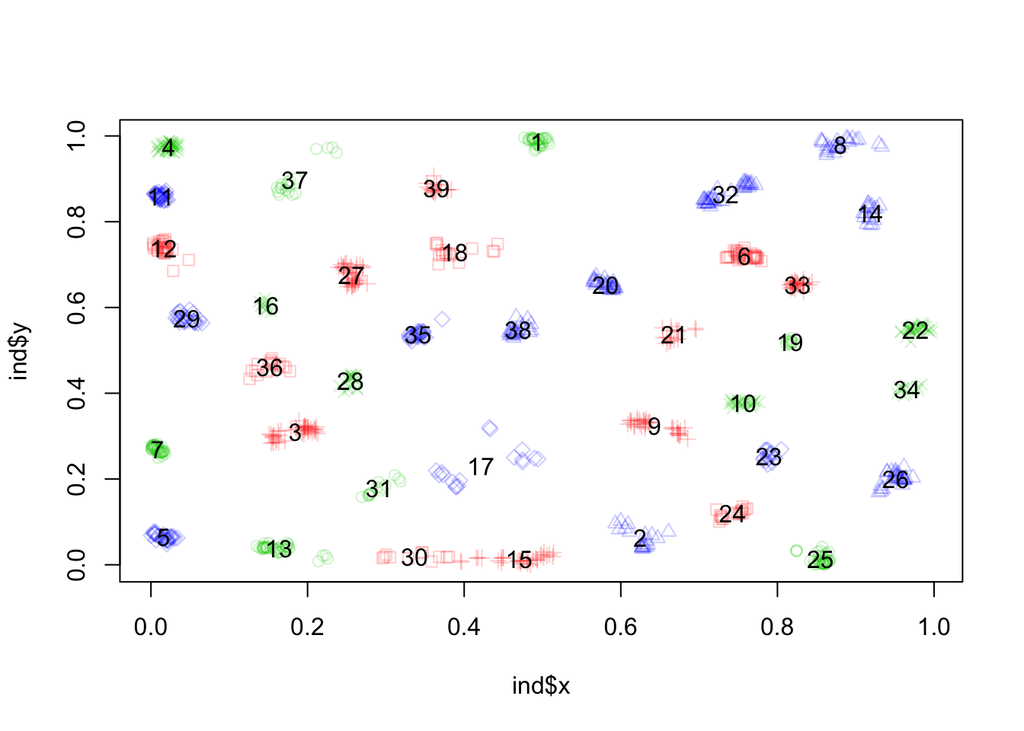

```r
  # note that phenotype 1 and phenotype 2 are the same thing
   k <- max(ind$pop)
   plot(ind$x, ind$y, pch=ind$pop%%6, col=adjustcolor(ind$pop%%3+2, alpha=0.2))
   text(tapply(ind$x, ind$pop, mean), tapply(ind$y, ind$pop, mean), label=1:k)
```

```r
  # check your sample sizes
     table(ind$pop)
```

```
##
##  1  2  3  4  5  6  7  8  9 10 11 12 13 14 15 16 17 18 19 20 21 22 23 24 25
## 35 20 41 42 29 35 42 24 32 26 32 31 41 17 32 11 17 17 10 29 16 33 15 17 39
## 26 27 28 29 30 31 32 33 34 35 36 37 38 39
## 30 40 20 24 11 14 37 27 12 25 18 19 23 17
```

## Calculate variables required for `OutFLANK()` function

Here are the columns required for the input data frame. They should have these names, but order does not matter:

- `$LocusName`: a character string that uniquely names each locus.
- `$FST`: $F_{ST}$ calculated for this locus by Weir and Cockerham (1984). (Kept here to report the unbiased $F_{ST}$ of the results)
- `$T1`: The numerator of the estimator for $F_{ST}$ (necessary, with $T2, to calculate mean $F_{ST}$)
- `$T2`: The denominator of the estimator of $F_{ST}$
- `$FSTNoCorr`: $F_{ST}$ calculated for this locus without sample size correction. (See below for the functions used to calculate this and the next two columns)
- `$T1NoCorr`: The numerator of the estimator for $F_{ST}$ without sample size correction (necessary, with $T2$, to find mean $F_{ST}$)
- `$T2NoCorr`: The denominator of the estimator of $F_{ST}$ without sample size correction
- `$He`: The heterozygosity of the locus (used to screen out low heterozygosity loci that have a different distribution)

We are going to use the `MakeDiploidFSTMat()` function to calculate these variables from the SNP data:

- SNPdata has individuals in rows and loci in columns, with a count (0,1,2) of each reference allele (missing data is 9)
- locusNames indicate the names of the loci in columns
- popNames indicate the population origin of individuals in rows

```r
 FstDataFrame <- MakeDiploidFSTMat(SNPdata,locinames,ind$pop)
```

```
## Calculating FSTs, may take a few minutes...
```

```r
 head(FstDataFrame)
```

```
##   LocusName        He         FST           T1          T2  FSTNoCorr
## 1   2_55279 0.0019980 0.019790770 1.979198e-05 0.001000061 0.03858870
## 2   3_81812 0.0069755 0.001076022 3.754883e-06 0.003489596 0.02054829
## 3  5_174034 0.0148875 0.019617093 1.461786e-04 0.007451594 0.03829351
## 4  5_190924 0.0256620 0.038214677 4.911262e-04 0.012851769 0.05758598
## 5   2_47972 0.0059820 0.002318598 6.938843e-06 0.002992689 0.02175268
## 6   2_58099 0.0740355 0.014041215 5.202382e-04 0.037050793 0.03282613
##       T1NoCorr    T2NoCorr meanAlleleFreq
## 1 3.859380e-05 0.001000132         0.9990
## 2 7.171053e-05 0.003489854         0.9965
## 3 2.853679e-04 0.007452122         0.9925
## 4 7.401361e-04 0.012852714         0.9870
## 5 6.510381e-05 0.002992910         0.9970
## 6 1.216321e-03 0.037053434         0.9615
```

## Evaluations prior to running OutFLANK

### Check for loci with low sample sizes or unusual values of uncorrected $F_{ST}$

The procedure implemented in `OutFLANK()` will use a measure of $F_{ST}$ uncorrected for sample size, because correction for sample size results in negative values of FST that cannot be fit by a chi-square distribution. Assuming all loci have equal sample sizes, the ranks of the uncorrected FSTs (`$FSTNoCorr`) are equivalent to the ranks of the FSTs that have been corrected for sample size (`FST`).

Let’s plot the corrected vs. uncorrected FSTs:

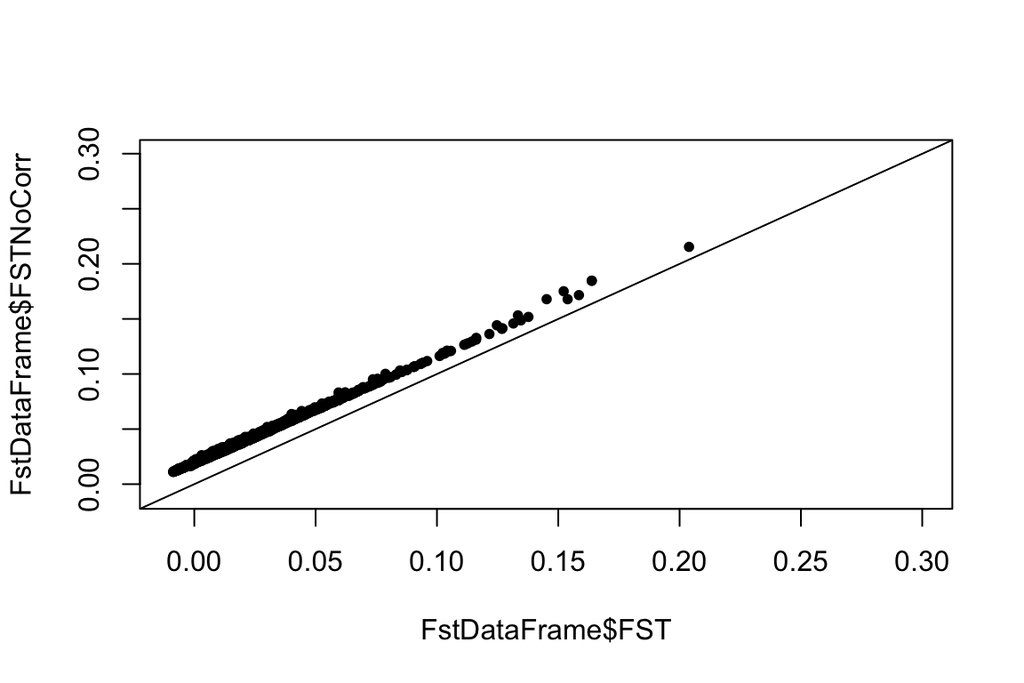

```r
plot(FstDataFrame$FST, FstDataFrame$FSTNoCorr,
     xlim=c(-0.01,0.3), ylim=c(-0.01,0.3),
     pch=20)
abline(0,1)
```

Note how the distribution of `$FSTNoCorr` is shifted slightly higher than the corrected `$FST` distribution, but the ranks are the same. Sample size correction decreases the value of $F_{ST}$. In this dataset, no loci are missing any data, but this step is recommended for real data. Loci with unusual sample sizes will be outliers in this plot.

### What if a locus has low sample size?

```r
SNPdata_missing <- SNPdata
missing <- sample(1:nrow(SNPdata_missing), 500, replace=FALSE)
SNPdata_missing[missing,1] <- 9
FstDataFrame_missing <- MakeDiploidFSTMat(SNPdata_missing,locinames,ind$pop)
```

```
## Calculating FSTs, may take a few minutes...
```

[figure not shown]

```r
  plot(FstDataFrame_missing$FST, FstDataFrame_missing$FSTNoCorr, xlim=c(-0.01,0.3), ylim=c(-0.01,0.3), pch=20)
  ## Highlight the SNP that is missing a lot of data
  points(FstDataFrame_missing$FST[1], FstDataFrame_missing$FSTNoCorr[1], col="blue", pch=8, cex=1.3)
  abline(0,1)
```

### Check if $F_{ST}$ distribution looks chi-squared distributed

Low frequency variants (rare alleles) have a statistical behavior that violate the assumptions. There is an option to remove these in the OutFLANK function.

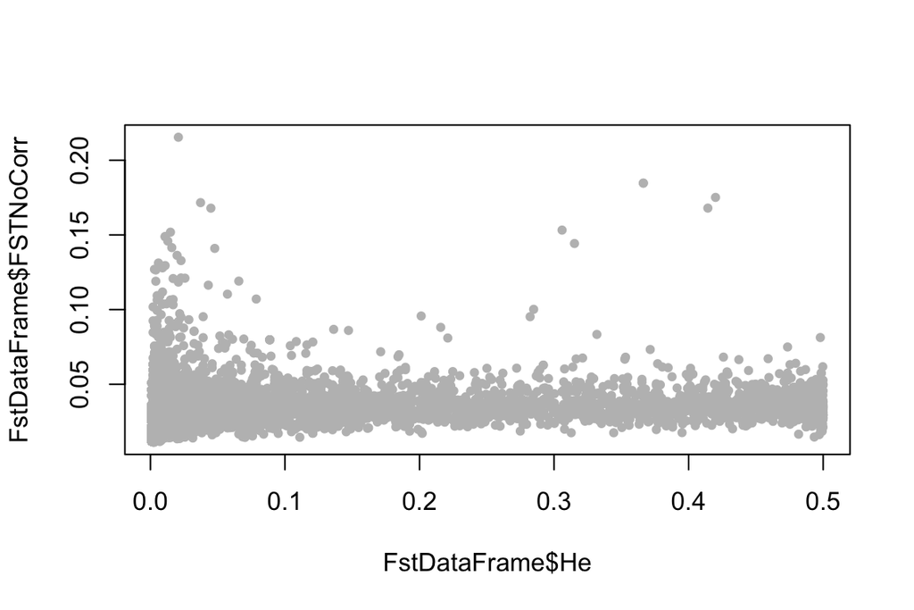

```r
  plot(FstDataFrame$He, FstDataFrame$FSTNoCorr, pch=20, col="grey")
```

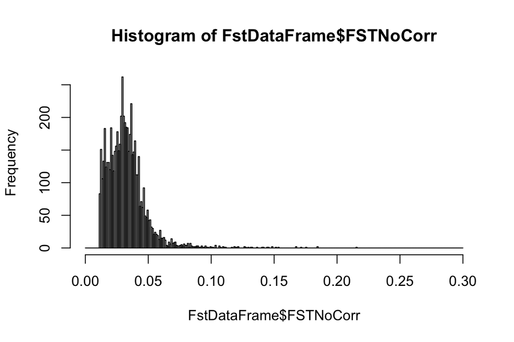

```r
    # Note the large FST values for loci with low heterozygosity (He < 0.1)

  hist(FstDataFrame$FSTNoCorr, breaks=seq(0,0.3, by=0.001))
```

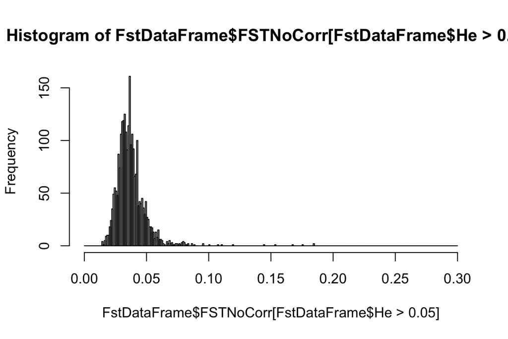

```r
    # Note how, when all loci are included, this doesn't look chi-square distributed
  hist(FstDataFrame$FSTNoCorr[FstDataFrame$He>0.05], breaks=seq(0,0.3, by=0.001))
```

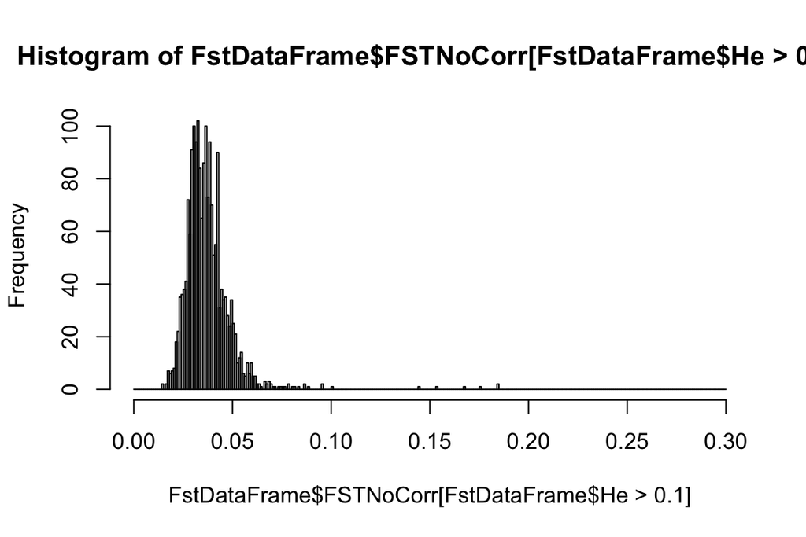

```r
    # Removing low Heterozygosity variants results in a more chi-square looking FST distribution
  hist(FstDataFrame$FSTNoCorr[FstDataFrame$He>0.1], breaks=seq(0,0.3, by=0.001))
```

```r
    # Removing low Heterozygosity variants results in a more chi-square looking FST distribution
```